# Lab 2: p-Hacking & False Discovery Rate

Das Multiplizitätsproblem verstehen und kontrollieren

Autor:in

Prof. Dr. Jörg Schoder

Veröffentlichungsdatum

17. März 2026

## Lernziele und Überblick

**HinweisLernziele dieses Labs**

- p-Hacking durch Simulation **direkt erfahren**
- Verstehen warum α = 0.05 bei vielen simultanen Tests versagt
- Die **Benjamini-Hochberg-Prozedur** zur FDR-Kontrolle anwenden
- Den Unterschied zwischen **FDR** und **FWER** (Bonferroni) kennen

**WichtigDie zentrale Frage dieses Labs**

> „Wenn ich 100 zufällige Variablen auf Zusammenhang mit dem Bundesliga-Marktwert teste — wie viele davon sind bei α = 0.05 rein zufällig signifikant?”

**Erwartete Antwort:** $100 \times 0.05 = 5$ falsche Treffer.

**Das ist kein Fehler — das ist Mathematik.**

**TippZeitplanung**

⏱ **25 Minuten** — Pflichtaufgaben (A1–A3) zuerst, Bonusaufgaben wenn Zeit bleibt.

## Teil 1: p-Hacking simulieren

### Zufällige Variablen testen

Wir generieren 100 vollständig zufällige Variablen (ohne echten Zusammenhang mit dem Marktwert) und testen jede einzeln gegen `log_value`.

**Code anzeigen**

```r
set.seed(42)
n_tests <- 100
n_obs   <- nrow(tbl_buli)

p_values_random <- map_dbl(1:n_tests, function(i) {
  tbl_sim <- tbl_buli %>%
               mutate(rand_var = rnorm(n_obs))
  lm(log_value ~ rand_var, data = tbl_sim) %>%
    get_regression_table() %>%
    filter(term == "rand_var") %>%
    pull(p_value)
})

# Ergebnis
n_signifikant <- sum(p_values_random < 0.05)
cat("Signifikant bei α = 0.05:", n_signifikant, "von", n_tests, "Tests\n")
```

```
Signifikant bei α = 0.05: 4 von 100 Tests
```

**Code anzeigen**

```r
cat("Erwartet (theoretisch):   ", n_tests * 0.05)
```

```
Erwartet (theoretisch):    5
```

**WarnungAchtung: Das ist kein Fehler!**

### Visualisierung der p-Wert-Verteilung

**Code anzeigen**

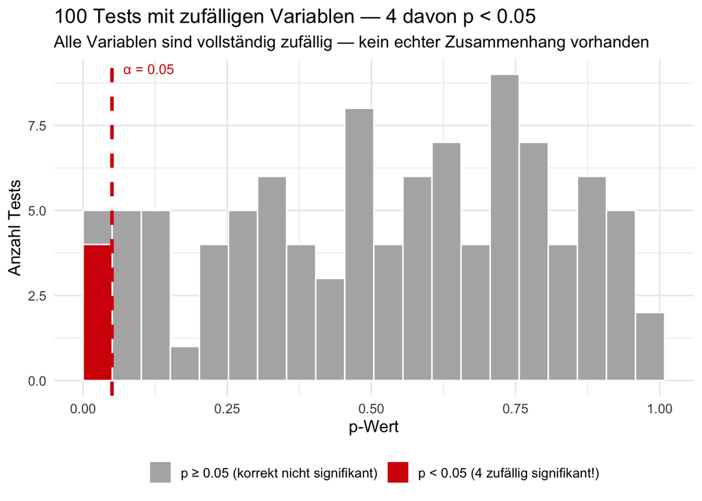

```r
tibble(
  test_nr     = 1:n_tests,
  p_value     = p_values_random,
  signifikant = p_values_random < 0.05
) %>%
  ggplot(aes(x = p_value, fill = signifikant)) +
  geom_histogram(bins = 20, color = "white", boundary = 0) +
  geom_vline(xintercept = 0.05, color = "#D50006",
             linetype = "dashed", linewidth = 1.2) +
  annotate("text", x = 0.07, y = Inf, label = "α = 0.05",
           hjust = 0, vjust = 1.5, color = "#D50006", size = 3.5) +
  scale_fill_manual(
    values = c("TRUE"  = "#D50006", "FALSE" = "#b3b2b2"),
    labels = c("TRUE"  = glue::glue("p < 0.05 ({n_signifikant} zufällig signifikant!)"),
               "FALSE" = "p ≥ 0.05 (korrekt nicht signifikant)")
  ) +
  labs(
    x        = "p-Wert",
    y        = "Anzahl Tests",
    fill     = NULL,
    title    = glue::glue("100 Tests mit zufälligen Variablen — {n_signifikant} davon p < 0.05"),
    subtitle = "Alle Variablen sind vollständig zufällig — kein echter Zusammenhang vorhanden"
  ) +
  theme_minimal(base_size = 12) +
  theme(legend.position = "bottom")
```

**HinweisWarum ist die p-Wert-Verteilung gleichmäßig?**

Unter $H_0$ (kein echter Effekt) sind p-Werte **gleichmäßig verteilt** auf [0, 1]. Das bedeutet: in jedem Intervall der Breite 0.05 liegt etwa 5% aller p-Werte — einschließlich des Intervalls [0, 0.05].

## Teil 2: Das reale Problem im Bundesliga-Datensatz

Jetzt testen wir alle numerischen Variablen des echten Datensatzes gegen `log_value` — ohne inhaltliche Hypothesen.

**Code anzeigen**

```r
# Welche numerischen Variablen gibt es?
tbl_buli_raw %>%
  select(where(is.numeric)) %>%
  names()
```

```
[1] "season_start_year"        "player_age"
[3] "player_market_value_euro"
```

**Code anzeigen**

```r
# Datensatz für Tests vorbereiten
tbl_test <- tbl_buli_raw %>%
              mutate(
                log_value = log(player_market_value_euro),
                age       = lubridate::year(Sys.Date()) -
                            lubridate::year(player_dob)
              ) %>%
              select(log_value, where(is.numeric),
                     -player_market_value_euro)

# Alle Variablen gegen log_value testen
p_values_real <- tbl_test %>%
  select(-log_value) %>%
  names() %>%
  map_dfr(function(var) {
    tryCatch({
      p <- lm(as.formula(glue::glue("log_value ~ `{var}`")),
              data = tbl_test) %>%
            broom::tidy() %>%
            filter(term != "(Intercept)") %>%
            pull(p.value)
      tibble(variable = var, p_value = p[1])
    }, error = function(e) {
      tibble(variable = var, p_value = NA_real_)
    })
  }) %>%
  filter(!is.na(p_value)) %>%
  arrange(p_value)

# Top 10 — scheinbar signifikante Variablen
p_values_real %>%
  head(10) %>%
  gt() %>%
  fmt_number(columns = p_value, decimals = 4) %>%
  tab_style(
    style     = cell_fill(color = "#fff0f0"),
    locations = cells_body(rows = p_value < 0.05)
  ) %>%
  tab_options(table.font.size = "13px") %>%
  tab_footnote("Rot = p < 0.05 ohne Korrektur")
```

| variable | p_value |
| --- | --- |
| age | 0.0454 |

Rot = p < 0.05 ohne Korrektur

**WarnungWie viele sind signifikant — ohne Korrektur?**

1 von 1 Variablen sind p < 0.05. Aber wie viele davon sind echte Effekte?

## Teil 3: Benjamini-Hochberg — FDR kontrollieren

### Grundidee der FDR

Statt jedes einzelne α zu kontrollieren (**FWER**, z.B. Bonferroni), kontrolliert die **False Discovery Rate** den Anteil falscher Entdeckungen unter allen Entdeckungen:

$$\text{FDR} = \frac{\text{Falsche Entdeckungen}}{\text{Alle Entdeckungen}}$$

**Benjamini-Hochberg-Prozedur:**

1. p-Werte aufsteigend sortieren: $p_{(1)} \leq p_{(2)} \leq \cdots \leq p_{(m)}$
2. Für gewünschtes FDR-Niveau $q$: finde größtes $k$ mit $p_{(k)} \leq \frac{k}{m} \cdot q$
3. Tests $1, \ldots, k$ als signifikant erklären

In R: `p.adjust(p_values, method = "BH")`

### Korrektur anwenden

**Code anzeigen**

```r
p_values_adjusted <- p_values_real %>%
  mutate(
    p_bonferroni      = p.adjust(p_value, method = "bonferroni"),
    p_BH              = p.adjust(p_value, method = "BH"),
    sig_roh           = p_value      < 0.05,
    sig_bonferroni    = p_bonferroni < 0.05,
    sig_BH            = p_BH        < 0.05
  )

# Vergleich der Methoden
p_values_adjusted %>%
  summarise(
    `Ohne Korrektur`      = sum(sig_roh,        na.rm = TRUE),
    `Bonferroni`          = sum(sig_bonferroni,  na.rm = TRUE),
    `BH (FDR)`            = sum(sig_BH,          na.rm = TRUE)
  ) %>%
  pivot_longer(everything(),
               names_to  = "Methode",
               values_to = "Signifikant") %>%
  gt() %>%
  tab_style(
    style     = cell_fill(color = "#f0fff0"),
    locations = cells_body(rows = Methode == "BH (FDR)")
  ) %>%
  tab_options(table.font.size = "14px") %>%
  tab_footnote("Grün = empfohlene Methode für viele simultane Tests")
```

| Methode | Signifikant |
| --- | --- |
| Ohne Korrektur | 1 |
| Bonferroni | 1 |
| BH (FDR) | 1 |

Grün = empfohlene Methode für viele simultane Tests

### Visualisierung

**Code anzeigen**

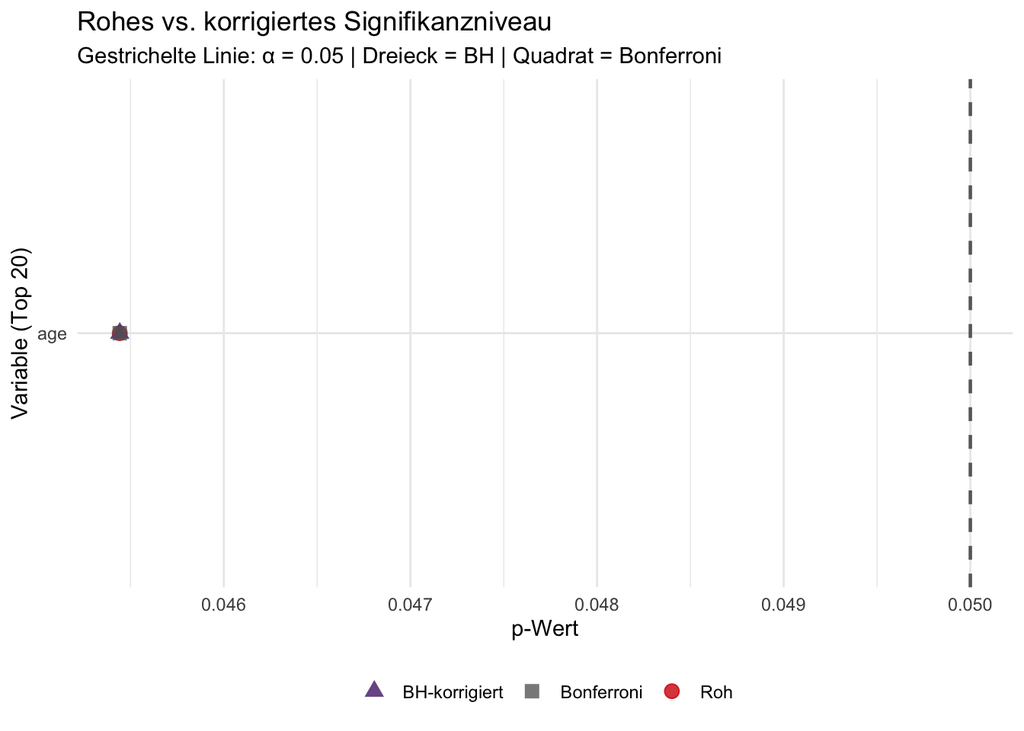

```r
p_values_adjusted %>%
  slice_head(n = 20) %>%
  mutate(variable = fct_reorder(variable, p_value)) %>%
  ggplot(aes(y = variable)) +
  geom_point(aes(x = p_value,    color = "Roh"),
             size = 3, alpha = 0.8) +
  geom_point(aes(x = p_BH,       color = "BH-korrigiert"),
             size = 3, alpha = 0.8, shape = 17) +
  geom_point(aes(x = p_bonferroni, color = "Bonferroni"),
             size = 3, alpha = 0.8, shape = 15) +
  geom_vline(xintercept = 0.05, linetype = "dashed",
             color = "#686868", linewidth = 0.8) +
  scale_color_manual(
    values = c("Roh"           = "#D50006",
               "BH-korrigiert" = "#502479",
               "Bonferroni"    = "#686868")
  ) +
  labs(
    x        = "p-Wert",
    y        = "Variable (Top 20)",
    color    = NULL,
    title    = "Rohes vs. korrigiertes Signifikanzniveau",
    subtitle = "Gestrichelte Linie: α = 0.05 | Dreieck = BH | Quadrat = Bonferroni"
  ) +
  theme_minimal(base_size = 11) +
  theme(legend.position = "bottom")
```

**HinweisWann welche Methode?**

| Situation | Methode | Begründung |
| --- | --- | --- |
| 1 Test, klare Hypothese | α = 0.05 klassisch | Kein Multiplizitätsproblem |
| Wenige Tests (5–20) | **Bonferroni** | Konservativ, kontrolliert FWER |
| Viele Tests (>50) | **BH (FDR)** | Weniger konservativ, mehr Power |
| Data Mining, explorative Analyse | **BH (FDR)** | Standard in Data Science |

## Aufgaben

### Pflichtaufgaben

**Vorsicht A1: p-Hacking-Simulation skalieren**

Führen Sie die Simulation mit `n_tests = 1000` durch.

1. Wie viele von 1000 zufälligen Tests sind signifikant?
2. Entspricht das der theoretischen Erwartung ($1000 \times 0.05 = 50$)?
3. Was würde passieren wenn ein Forscher diese 1000 Tests durchführt und nur die signifikanten publiziert?

**Vorsicht A2: Bonferroni vs. BH**

Interpretieren Sie den Vergleich der drei Methoden in der Tabelle oben.

**Vorsicht A3: Allgemeine Break-Even-Formel**

In der Vorlesung haben wir gezeigt:

$$p_{\text{A}} > \frac{c(\text{FP})}{c(\text{FP}) + c(\text{FN})}$$

Angenommen die FDR-Korrektur erhöht Ihre Zuversicht, dass ein signifikanter Befund echt ist. Wie verändert das Ihren geschätzten $p_{\text{A}}$ für den Bundesliga-Transfer? Lohnt der Kauf bei BH-korrigiertem Befund eher?

### Bonusaufgaben

**Tipp B1: p-Hacking nachstellen**

Simulieren Sie das klassische p-Hacking-Szenario:

```r
# Forscher testet 20 Variablen und berichtet nur signifikante
set.seed(1)
ergebnisse <- map_dfr(1:20, function(i) {
  tbl_sim <- tbl_buli %>% mutate(x = rnorm(n()))
  p <- lm(log_value ~ x, data = tbl_sim) %>%
         broom::tidy() %>%
         filter(term == "x") %>%
         pull(p.value)
  tibble(test = i, p_value = p, signifikant = p < 0.05)
})
filter(ergebnisse, signifikant)
```

Wie viele „Entdeckungen” werden publiziert? Was wäre die korrekte Schlussfolgerung?

**Tipp B2: xkcd Significant**

Lesen Sie: [xkcd: Significant](https://xkcd.com/882/)

Erklären Sie den Witz statistisch präzise — und benennen Sie welche der p-Hacking-Praktiken aus diesem Lab dort dargestellt wird.

**Tipp B3: FDR vs. FWER**

Recherchieren Sie den Unterschied zwischen **FDR** (False Discovery Rate) und **FWER** (Family-Wise Error Rate).

- In welchem Kontext ist FWER wichtiger als FDR?
- Nennen Sie ein medizinisches und ein Data-Science-Beispiel wo die Wahl der Methode eine unterschiedliche Entscheidung erzeugen würde.

## Zusammenfassung

**WichtigKernbotschaften dieses Labs**

1. **Multiplizitätsproblem:** Bei $m$ Tests mit α = 0.05 sind im Schnitt $m \times 0.05$ Ergebnisse zufällig signifikant — auch ohne echten Effekt.
2. **p-Hacking:** Selektives Berichten nur signifikanter Ergebnisse verzerrt die wissenschaftliche Literatur systematisch.
3. **FDR (Benjamini-Hochberg):** Kontrolliert den *Anteil* falscher Entdeckungen — weniger konservativ als Bonferroni, deshalb Standard in Data Science.
4. **Praktische Faustregel:**
   - 1 Test, klare Hypothese → α = 0.05
   - Wenige Tests → Bonferroni
   - Viele Tests / Data Mining → BH (FDR)

**HinweisÜberleitung zum nächsten Block**

Selbst wenn ein Befund **echt signifikant** ist (nach FDR-Korrektur) — bedeutet das noch nicht, dass er **praktisch relevant** ist. Das ist das Thema des nächsten Blocks: Effektstärken und der Unterschied zwischen statistischer und praktischer Signifikanz.